# Taller 3 individual

Kenneth Roy Cabrera Torres

16 de abril de 2018

```r
library(readxl)
```

## Planteamiento del problema.

Se realiza un diseño factorial 3 $\times$ 2 con 10 réplicas para investigar el hinchamiento del catalizador después de la [extrusion](http://www.plastisax.com/el-proceso-de-extrusion-soplado) en la fabricación de botellas de polietileno de alta densidad. El catalizador se utiliza en la obtención de dicho polietileno. Los factores investigados son: molde (con dos niveles) y B: Catalizador (con tres niveles).

Los datos obtenidos se muestran en la siguiente tabla:

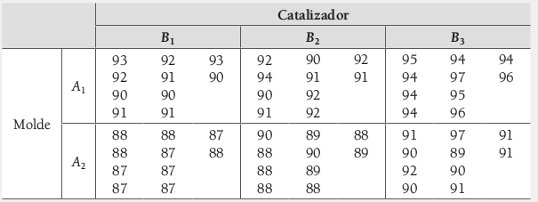

### Aleatorización

En la tabla con los datos se muestra el orden de aleatorización en el cual se realizó el experimento.

```r
library(readxl)
botellas <- read_excel("hichamiento.xlsx")
botellas$molde <- factor(botellas$molde)
botellas$catalizador <- factor(botellas$catalizador)
```

```r
botellas
```

```
## # A tibble: 60 x 5
##    molde catalizador hinchamiento replica  oden
##    <fct> <fct>              <dbl>   <dbl> <dbl>
##  1 A1    B1                   93.      1.    4.
##  2 A1    B1                   92.      2.    8.
##  3 A1    B1                   90.      3.   13.
##  4 A1    B1                   91.      4.   21.
##  5 A1    B1                   92.      5.   27.
##  6 A1    B1                   91.      6.   34.
##  7 A1    B1                   90.      7.   41.
##  8 A1    B1                   91.      8.   43.
##  9 A1    B1                   93.      9.   49.
## 10 A1    B1                   90.     10.   56.
## # ... with 50 more rows
```

### Asignación de réplicas.

En la siguiente tabla se muestra la asignación de la identificación de cinco de las diez réplicas realizadas.

```r
library(readxl)
asignacion <- read_excel("asignacion.xlsx", skip = 10)
data.frame(asignacion)
```

```
##           nombres Réplicas.a.utilizar X__1 X__2 X__3 X__4
## 1         Esteban                   1    5    8    9   10
## 2         Eduardo                   3    6    7    8   10
## 3          Camilo                   1    4    6    8    9
## 4         Johanna                   2    3    5    6    8
## 5          Yesica                   1    2    5    6   10
## 6        Angelica                   1    2    5    7    9
## 7       Alexandra                   1    4    6    7    8
## 8      Juan David                   1    2    4    5   10
## 9            Sara                   1    2    6    7    8
## 10      Valentina                   3    4    6    8   10
## 11          Laura                   3    4    7    9   10
## 12 Juan Alejandro                   3    5    6    9   10
## 13          Pablo                   3    4    5    7    8
```

## Resultados esperados.

Realice un análisis estadístico que contenga como mínimo:

1. Una corta introducción o contexto al problema (No más de tres párrafos, con referencia bibliográfica).
2. Realice un análisis exploratorio de las cinco réplicas asignadas.
3. Plantee el modelo para los datos.
4. Encuentre el modelo óptimo.
5. Realice los diagnósiticos pertinentes del modelo.
6. Realice una comparación de medias.
7. Muestre la predicción del modelo o el comportamiento del modelo final.
8. Estime el error aleatorio e indique cual sería el nivel de detección con el que posiblemente se construyó el experimento.
9. Conclusiones.
10. Recomendaciones.

## Documentos a entregar.

- Base de datos utilizada en el análisis.
- Código en formato “.Rmd”.
- Informe con los resultados (sin el código) en formato “.html”

## Fecha de entrega.

Jueves 26 de abril de 2018 antes de las 23:59 hora de Colombia al correo **krcabrer@unal.edu.co** y no olvidar escribir en asunto **[MEDE]**.